```python
from IPython.display import Image
from IPython.display import HTML
import IPython.core.display as di
# Example: di.display_html('<h3>%s:</h3>' % str, raw=True)
di.display_html('<script>jQuery(function() {if (jQuery("body.notebook_app").length == 0) { jQuery(".input_area").toggle(); jQuery(".prompt").toggle();}});</script>', raw=True)
```

# Molecular generative model based on conditional variational autoencoder for de novo molecular design

## Method

### Conditional Variational AutoEncoder(CVAE)

CVAE는 VAE의 한 종류로, encoding과 decoding 과정에서 특정 제약 조건을 걸어주는 것에 차이점이 있다. 즉 VAE의 objective funciton에 conditional information을 삽입시켜준 것이 CVAE의 objective function이다. 얼핏 보면 jointly trained VAE model과 비슷하다고 볼 수 있지만 중요한 다른 점이 있다. 우선 아래의 그림은 jointly trained VAE model을 나타낸 것이다.

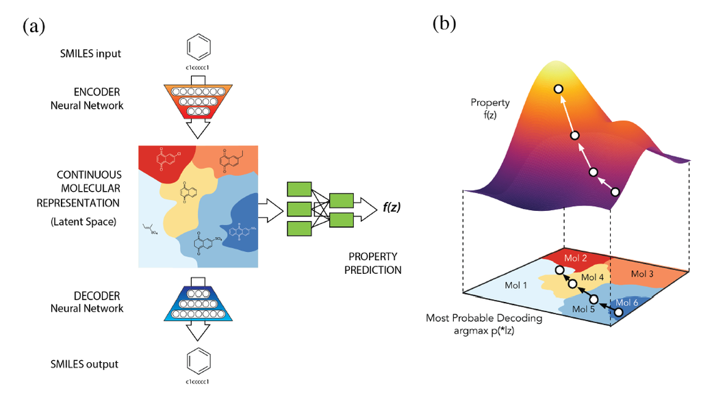

```python
Image(filename = '../img/jointly training VAE.png')
```

(a)는 보통의 VAE와 같은 구조를 그린 것으로, encoder를 통해서 latent vector들이 만들어지고 이들이 latent space를 구성하는 것을, 그것으로부터 decoder를 통해 input과 비슷한 output을 만들어내는 것을 보여준다. (b)는 latent vector들로부터, 분자의 물성들을 조절하는 과정에 대한 그림이다. (a)에서 latent representation $z$로부터 분자의 물성을 예측할 수 있는 모델 $f(z)$를 만들고 난 후에 그 모델을 물성의 특정한 값을 가지도록 하는 새로운 latent representation $z$를 찾아내도록 optimize시킬 수 있다. 이렇게 해서 만들어진 latent representation이 decoder를 통해 output으로 만들어진다면, 우리가 원하는 물성을 가지는 구조의 분자가 만들어지게 되는 것이다. 모델적인 측면에서 다시 설명을 하자면, 보통 loss function을 일반적인 VAE에서는 input X와 output X'의 비슷한 정도를 나타내는 reconstruction loss와 encoder, decoder의 유사성을 나타낸 KL divergence loss를 사용하여 back propagation을 하고 결론적으로 input X와 유사한 output X', 비슷한 encoder와 decoder를 만든다. Jointly trained VAE 같은 경우, 이 loss function에 latent vector를 input vector로 하여 Neural Network를 통해 물성을 예측하도록 하고 이 예측한 값과 실제 분자의 물성 값들의 차이를 loss로써 추가하여 back propagation을 돌리는 것이다. 그렇게 된다면 실제의 분자에서 물성이 우리가 원하는 값으로 치우친 새로운 분자가 만들어진다는 것이다.  
CVAE는 jointly trained VAE와는 다르게, 분자의 물성이 encoder와 decoder에 직접적으로 포함되어 있다. 즉, encoder를 거쳐서 나온 latent vector가 두 가지 파트로 구성이 되는데 첫 번째는 목표로하는 분자의 성질을 매핑한 것이고 두 번째는 그 분자의 구조와 다른 성질들이다. 결국, 아래의 figure1에 나와 있는 것처럼, 우리가 원하는 분자의 성질을 가지는 분자가 latent vector에 기준이 되는 벡터를 만들어 넣어주기만 하면 decoder를 통해 만들어질 수 있는 것이다.

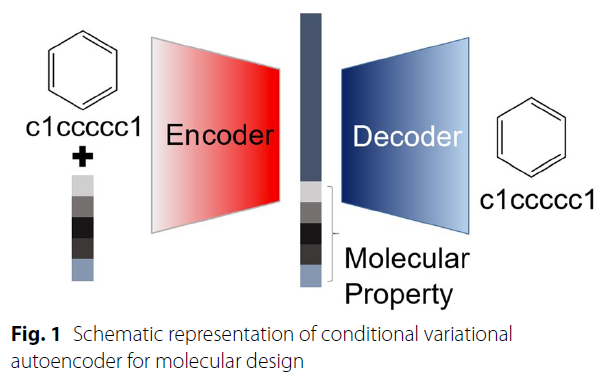

```python
Image(filename = '../img/CVAE.png')
```

이러한 CVAE는 분자의 구조와 그 성질이 굉장히 밀접한 연관성을 가지지만 않으면 구조와 물성을 따로 조절할 수 있다는 강점을 가진다. 이 방식은 물질의 구조를 크게 바꾸지 않으면서 물성을 바꾸고자 할 때 요긴하게 쓰일 수 있다. 또한, jointly trained VAE와 다르게 optimization 과정이 따로 필요 없다.

## Model construction & PreProcessing

1. 분자를 나타내는 SMILES의 끝에 SMILES가 끝났다는 의미의 'E'를 달아준다.
2. 수정된 SMILES string을 one-hot vector로 표현한다.
3. 300 크기의 embedding vector로 one-hot vector를 변환한다.
4. 변환된 벡터에 MW, logP, HBD, HBA, TPSA(분자의 물성들)에 대한 정보를 가진 5 크기의 condition vector를 붙여준 것을 최종적인 input vector로 둔다. 이 때 MW, logP, TPSA 값들은 -1.0에서 1.0으로 normalize 시켜준다.
5. Input vector를 500개의 hidden nodes를 가진 3-layer LSTM encoder를 거치게 하여 latent vector들을 만든다. 이 때 처음 300개의 성분은 분자의 구조에 대한 정보를, 마지막 5개의 성분은 분자의 물성에 해당하는 정보를 가진다(CVAE).
6. condition vector에 해당하는 분자의 물성을 가진 분자를 생성하기 위해, RNN decoder의 cell은 120회 동안 unrolled된다.
7. Decoder를 거쳐 나온 output은 softmax layer를 거치고, reconstruction error는 cross entropy error를 통해 판단한다.
8. output vector를 다시 input one-hot vector와 같은 dimension의 vector로 만들어준 후에 softmax layer를 거친다.
9. encoder와 decoder는 CVAE의 cost function을 최소화하기 위해 optimized된다.
10. 120개의 문자 안에 'E'가 나오지 않으면 유효하지 않은 것으로 해석하여 버린다.
11. output vector를 SMILES로 변환한다.